# Tutorial 5 R Solutions

2024-05-10

In this tutorial we will return to the [Public Health Scotland around Stroke Activity](https://www.opendata.nhs.scot/dataset/scottish-stroke-statistics/resource/47656572-e196-40c8-83e8-08b0b223b2e6) dataset that we used in last week’s tutorial. We will also be using the [Health Board Labels](https://www.opendata.nhs.scot/dataset/geography-codes-and-labels/resource/652ff726-e676-4a20-abda-435b98dd7bdc) dataset.

The aim of this tutorial is to give you some (guided) hands-on experience joining and reshaping tibbles, as well as to reinforce some of the learning we have done across the course. There are 8 tasks.

```r
Sys.setenv(TZ = "Europe/London") # set timezone (TZ argument) to whatever timezone you may be in. The allows the to packages to work as intended

library(tidyverse)
library(lubridate) # if using tidyverse 2.0.0 or later lubridate will be loaded with the tidyverse
```

```r
## read in the data sets
stroke_raw <- read_csv("https://www.opendata.nhs.scot/dataset/f5dcf382-e6ca-49f6-b807-4f9cc29555bc/resource/47656572-e196-40c8-83e8-08b0b223b2e6/download/stroke_activitybyhbr.csv")
hb <- read_csv("https://www.opendata.nhs.scot/dataset/9f942fdb-e59e-44f5-b534-d6e17229cc7b/resource/652ff726-e676-4a20-abda-435b98dd7bdc/download/hb14_hb19.csv")
```

It is always a good idea to quickly double check your data has been read in as expected. Since our data objects are tibbles (due to using `read_csv()`), there is a nice output in our RMD file that we can view by just calling the data object.

```r
stroke_raw
```

```
## # A tibble: 43,200 × 15
##    FinancialYear HBR     HBRQF AdmissionType AdmissionTypeQF AgeGroup AgeGroupQF
##    <chr>         <chr>   <chr> <chr>         <chr>           <chr>    <chr>
##  1 2013/14       S08000… <NA>  All           d               0-44 ye… <NA>
##  2 2013/14       S08000… <NA>  All           d               0-44 ye… <NA>
##  3 2013/14       S08000… <NA>  All           d               45-64 y… <NA>
##  4 2013/14       S08000… <NA>  All           d               45-64 y… <NA>
##  5 2013/14       S08000… <NA>  All           d               65-74 y… <NA>
##  6 2013/14       S08000… <NA>  All           d               65-74 y… <NA>
##  7 2013/14       S08000… <NA>  All           d               75plus … <NA>
##  8 2013/14       S08000… <NA>  All           d               75plus … <NA>
##  9 2013/14       S08000… <NA>  All           d               0-44 ye… <NA>
## 10 2013/14       S08000… <NA>  All           d               0-44 ye… <NA>
## # ℹ 43,190 more rows
## # ℹ 8 more variables: Sex <chr>, SexQF <chr>, Diagnosis <chr>,
## #   NumberOfDischarges <dbl>, NumberOfDischargesQF <chr>, CrudeRate <dbl>,
## #   CrudeRateQF <chr>, EASR <dbl>
```

```r
hb
```

```
## # A tibble: 18 × 5
##    HB        HBName                        HBDateEnacted HBDateArchived Country
##    <chr>     <chr>                                 <dbl>          <dbl> <chr>
##  1 S08000015 NHS Ayrshire and Arran             20140401             NA S920000…
##  2 S08000016 NHS Borders                        20140401             NA S920000…
##  3 S08000017 NHS Dumfries and Galloway          20140401             NA S920000…
##  4 S08000018 NHS Fife                           20140401       20180201 S920000…
##  5 S08000019 NHS Forth Valley                   20140401             NA S920000…
##  6 S08000020 NHS Grampian                       20140401             NA S920000…
##  7 S08000021 NHS Greater Glasgow and Clyde      20140401       20190331 S920000…
##  8 S08000022 NHS Highland                       20140401             NA S920000…
##  9 S08000023 NHS Lanarkshire                    20140401       20190331 S920000…
## 10 S08000024 NHS Lothian                        20140401             NA S920000…
## 11 S08000025 NHS Orkney                         20140401             NA S920000…
## 12 S08000026 NHS Shetland                       20140401             NA S920000…
## 13 S08000027 NHS Tayside                        20140401       20180201 S920000…
## 14 S08000028 NHS Western Isles                  20140401             NA S920000…
## 15 S08000029 NHS Fife                           20180202             NA S920000…
## 16 S08000030 NHS Tayside                        20180202             NA S920000…
## 17 S08000031 NHS Greater Glasgow and Clyde      20190401             NA S920000…
## 18 S08000032 NHS Lanarkshire                    20190401             NA S920000…
```

Below is an image showing where the different Health Boards are in Scotland on a map.

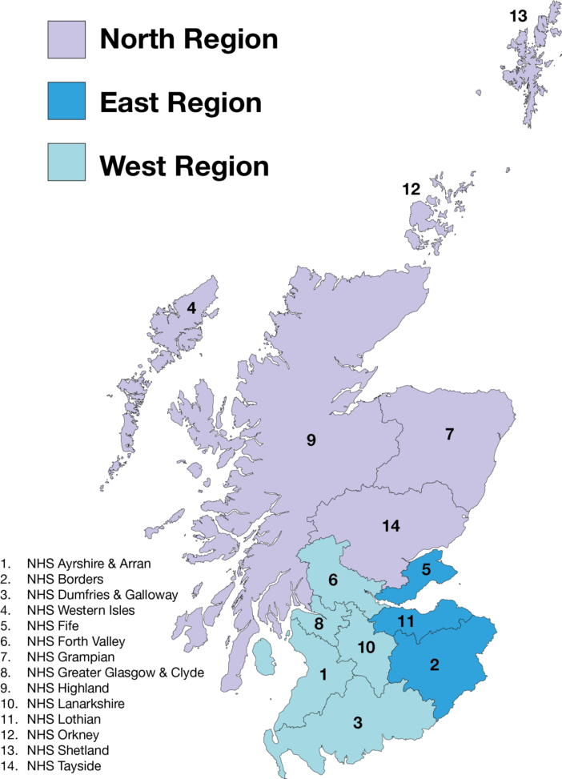

Scotland HB Map

## Question to solve

The question we are trying to answer with the data is:

> What is the average number of discharges with a stroke diagnosis by age group in the East region of Scotland for all admissions in the finanical year 2019/20 and 2020/21?

### Task 1

Looking at these two tibbles, what columns do you think are the linkage keys?

#### Task 1 Solution

In the `stroke_raw` data set there is `HBR` (health board of residence), which links to the `HB` column in the `hb` data set.

### Task 2

Join the Stroke activity data set with the [Health Board Labels](https://www.opendata.nhs.scot/dataset/geography-codes-and-labels/resource/652ff726-e676-4a20-abda-435b98dd7bdc) dataset into a new tibble called `stroke_join`.

In Task 1 above we identified the linkage key variable(s), which is the first step when wanting to complete a join. Next, you need to decide on the type of join you want to use and then implement this in code.

#### Task 2 Solution

Either a left join or full join would be appropriate. An inner join is not appropriate here as it removes 2880 observations from the `stroke_raw` data set. In this example solution, I have used a left join, with the `stroke_raw` data set on the left and the `hb` data set on the right (keeping all data from `stroke_raw` and only matching data from `hb`)

```r
stroke_join <- stroke_raw %>%
  left_join(hb, by = c("HBR" = "HB"))

stroke_join
```

```
## # A tibble: 43,200 × 19
##    FinancialYear HBR     HBRQF AdmissionType AdmissionTypeQF AgeGroup AgeGroupQF
##    <chr>         <chr>   <chr> <chr>         <chr>           <chr>    <chr>
##  1 2013/14       S08000… <NA>  All           d               0-44 ye… <NA>
##  2 2013/14       S08000… <NA>  All           d               0-44 ye… <NA>
##  3 2013/14       S08000… <NA>  All           d               45-64 y… <NA>
##  4 2013/14       S08000… <NA>  All           d               45-64 y… <NA>
##  5 2013/14       S08000… <NA>  All           d               65-74 y… <NA>
##  6 2013/14       S08000… <NA>  All           d               65-74 y… <NA>
##  7 2013/14       S08000… <NA>  All           d               75plus … <NA>
##  8 2013/14       S08000… <NA>  All           d               75plus … <NA>
##  9 2013/14       S08000… <NA>  All           d               0-44 ye… <NA>
## 10 2013/14       S08000… <NA>  All           d               0-44 ye… <NA>
## # ℹ 43,190 more rows
## # ℹ 12 more variables: Sex <chr>, SexQF <chr>, Diagnosis <chr>,
## #   NumberOfDischarges <dbl>, NumberOfDischargesQF <chr>, CrudeRate <dbl>,
## #   CrudeRateQF <chr>, EASR <dbl>, HBName <chr>, HBDateEnacted <dbl>,
## #   HBDateArchived <dbl>, Country <chr>
```

### Task 3

To answer our question outlined above, we do not need all of the columns currently in the `stroke_join` data set. Process the data to include only the variables needed to answer the question and save this processed data set into an object called `stroke`.

Check the data types of the remaining columns and change them if not appropriate.

**Hint** Beware of aggregate or summary level data, even in variables not needed to directly answer the question. Consulting the data dictionary (if provided) or doing data checks is crucial at this stage.

#### Task 3 solution

The variables we need to answer the question are `FinancialYear`, `AdmissionType`, `AgeGroup`, `Diagnosis`, `NumberOfDischarges`, and `HBName`. We also need `Sex` as we need to filter the data to include only the aggregate level `All` to avoid duplicate data, although `Sex` is not directly related to our question of interest.

```r
stroke <- stroke_join %>%
  select(
    FinancialYear, AdmissionType, AgeGroup, Sex,
    Diagnosis, NumberOfDischarges, HBName
  )

stroke
```

```
## # A tibble: 43,200 × 7
##    FinancialYear AdmissionType AgeGroup     Sex     Diagnosis NumberOfDischarges
##    <chr>         <chr>         <chr>        <chr>   <chr>                  <dbl>
##  1 2013/14       All           0-44 years   Males   Cerebrov…                 57
##  2 2013/14       All           0-44 years   Females Cerebrov…                 42
##  3 2013/14       All           45-64 years  Males   Cerebrov…                231
##  4 2013/14       All           45-64 years  Females Cerebrov…                209
##  5 2013/14       All           65-74 years  Males   Cerebrov…                244
##  6 2013/14       All           65-74 years  Females Cerebrov…                193
##  7 2013/14       All           75plus years Males   Cerebrov…                414
##  8 2013/14       All           75plus years Females Cerebrov…                449
##  9 2013/14       All           0-44 years   Males   Cerebrov…                 16
## 10 2013/14       All           0-44 years   Females Cerebrov…                  4
## # ℹ 43,190 more rows
## # ℹ 1 more variable: HBName <chr>
```

```r
glimpse(stroke)
```

```
## Rows: 43,200
## Columns: 7
## $ FinancialYear      <chr> "2013/14", "2013/14", "2013/14", "2013/14", "2013/1…
## $ AdmissionType      <chr> "All", "All", "All", "All", "All", "All", "All", "A…
## $ AgeGroup           <chr> "0-44 years", "0-44 years", "45-64 years", "45-64 y…
## $ Sex                <chr> "Males", "Females", "Males", "Females", "Males", "F…
## $ Diagnosis          <chr> "Cerebrovascular Disease", "Cerebrovascular Disease…
## $ NumberOfDischarges <dbl> 57, 42, 231, 209, 244, 193, 414, 449, 16, 4, 87, 40…
## $ HBName             <chr> "NHS Ayrshire and Arran", "NHS Ayrshire and Arran",…
```

It looks like all of the variables which are characters should in fact be factors.

```r
stroke <- stroke %>%
  mutate(
    FinancialYear = as.factor(FinancialYear),
    AdmissionType = as.factor(AdmissionType),
    AgeGroup = as.factor(AgeGroup),
    Sex = as.factor(Sex),
    Diagnosis = as.factor(Diagnosis),
    HBName = as.factor(HBName)
  )

## a more advanced and elegant solution is to using the across and where functions to coerce all characters to be factors since all of the variables we wanted to change were characters
stroke %>%
  mutate(across(where(is.character), as.factor))
```

```
## # A tibble: 43,200 × 7
##    FinancialYear AdmissionType AgeGroup     Sex     Diagnosis NumberOfDischarges
##    <fct>         <fct>         <fct>        <fct>   <fct>                  <dbl>
##  1 2013/14       All           0-44 years   Males   Cerebrov…                 57
##  2 2013/14       All           0-44 years   Females Cerebrov…                 42
##  3 2013/14       All           45-64 years  Males   Cerebrov…                231
##  4 2013/14       All           45-64 years  Females Cerebrov…                209
##  5 2013/14       All           65-74 years  Males   Cerebrov…                244
##  6 2013/14       All           65-74 years  Females Cerebrov…                193
##  7 2013/14       All           75plus years Males   Cerebrov…                414
##  8 2013/14       All           75plus years Females Cerebrov…                449
##  9 2013/14       All           0-44 years   Males   Cerebrov…                 16
## 10 2013/14       All           0-44 years   Females Cerebrov…                  4
## # ℹ 43,190 more rows
## # ℹ 1 more variable: HBName <fct>
```

```r
glimpse(stroke) # all ready to go!
```

```
## Rows: 43,200
## Columns: 7
## $ FinancialYear      <fct> 2013/14, 2013/14, 2013/14, 2013/14, 2013/14, 2013/1…
## $ AdmissionType      <fct> All, All, All, All, All, All, All, All, All, All, A…
## $ AgeGroup           <fct> 0-44 years, 0-44 years, 45-64 years, 45-64 years, 6…
## $ Sex                <fct> Males, Females, Males, Females, Males, Females, Mal…
## $ Diagnosis          <fct> Cerebrovascular Disease, Cerebrovascular Disease, C…
## $ NumberOfDischarges <dbl> 57, 42, 231, 209, 244, 193, 414, 449, 16, 4, 87, 40…
## $ HBName             <fct> NHS Ayrshire and Arran, NHS Ayrshire and Arran, NHS…
```

### Task 4

What is the shape of the `stroke` data currently? Is it in a suitable shape?

#### Task 4 Solution

The `stroke` data frame is currently in long format as we have a single column for each variable, which is indeed what we want. Long format makes it easier to manipulate and wrangle data. So we will keep it that way.

### Task 5

Now that we have our joined data set, it is important to inspect the data for any missing or aggregate values. We know from last week that this data set has many aggregate level responses! Check for the unique values of all 7 variables in `stroke`. Are there any unexpected findings?

#### Task 5 Solution

We know from last week that `AgeGroup` and `AdmissionType` each include aggregate level responses. For completeness sake I have included the code exploring these variables again here as well.

```r
## since we have converted the characters to be factors, we can use summary to get a summary of each variable in the dataset rather looking at each variable 1 by 1

stroke %>%
  summary()
```

```
##  FinancialYear     AdmissionType            AgeGroup         Sex
##  2013/14: 4320   All      :10800   0-44 years   :7200   All    :14400
##  2014/15: 4320   Elective :10800   45-64 years  :7200   Females:14400
##  2015/16: 4320   Emergency:10800   65-74 years  :7200   Males  :14400
##  2016/17: 4320   Transfer :10800   75plus years :7200
##  2017/18: 4320                     All          :7200
##  2018/19: 4320                     under75 years:7200
##  (Other):17280
##                       Diagnosis     NumberOfDischarges
##  Cerebrovascular Disease   :10800   Min.   :    0.0
##  Stroke                    :10800   1st Qu.:    2.0
##  Subarachnoid Haemorrhage  :10800   Median :   25.0
##  TIAs and related syndromes:10800   Mean   :  314.8
##                                     3rd Qu.:  167.0
##                                     Max.   :35410.0
##                                     NA's   :3697
##                        HBName
##  NHS Ayrshire and Arran   : 2880
##  NHS Borders              : 2880
##  NHS Dumfries and Galloway: 2880
##  NHS Fife                 : 2880
##  NHS Forth Valley         : 2880
##  (Other)                  :25920
##  NA's                     : 2880
```

The output print out for `FinancialYear` and `HBName`are cut off as there are many factor levels (more than 6), so we will check these variables individually. Otherwise, `AdmissionType`, `AgeGroup`, and `Sex` all have aggregate response levels and `NumberOfDischarges` and `HBName` have NAs.

```r
stroke %>%
  pull(FinancialYear) %>%
  summary() # or you could use levels()
```

```
## 2013/14 2014/15 2015/16 2016/17 2017/18 2018/19 2019/20 2020/21 2021/22 2022/23
##    4320    4320    4320    4320    4320    4320    4320    4320    4320    4320
```

```r
# no missing or aggregate level data here

stroke %>%
  pull(HBName) %>%
  summary()
```

```
##        NHS Ayrshire and Arran                   NHS Borders
##                          2880                          2880
##     NHS Dumfries and Galloway                      NHS Fife
##                          2880                          2880
##              NHS Forth Valley                  NHS Grampian
##                          2880                          2880
## NHS Greater Glasgow and Clyde                  NHS Highland
##                          2880                          2880
##               NHS Lanarkshire                   NHS Lothian
##                          2880                          2880
##                    NHS Orkney                  NHS Shetland
##                          2880                          2880
##                   NHS Tayside             NHS Western Isles
##                          2880                          2880
##                          NA's
##                          2880
```

Within `HBName` there are 14 health boards as expected but what could the NAs be? Well, we know from last week that HBR in the stroke data set included all of Scotland with the country code S92000003. Because we still have the unedited `stroke_raw` data, we can check if these missing values match up to the aggregate country level. Having a raw data frame version is super useful!

```r
stroke_raw %>%
  filter(HBR == "S92000003")
```

```
## # A tibble: 2,880 × 15
##    FinancialYear HBR     HBRQF AdmissionType AdmissionTypeQF AgeGroup AgeGroupQF
##    <chr>         <chr>   <chr> <chr>         <chr>           <chr>    <chr>
##  1 2013/14       S92000… d     All           d               0-44 ye… <NA>
##  2 2013/14       S92000… d     All           d               0-44 ye… <NA>
##  3 2013/14       S92000… d     All           d               45-64 y… <NA>
##  4 2013/14       S92000… d     All           d               45-64 y… <NA>
##  5 2013/14       S92000… d     All           d               65-74 y… <NA>
##  6 2013/14       S92000… d     All           d               65-74 y… <NA>
##  7 2013/14       S92000… d     All           d               75plus … <NA>
##  8 2013/14       S92000… d     All           d               75plus … <NA>
##  9 2013/14       S92000… d     Elective      <NA>            0-44 ye… <NA>
## 10 2013/14       S92000… d     Elective      <NA>            0-44 ye… <NA>
## # ℹ 2,870 more rows
## # ℹ 8 more variables: Sex <chr>, SexQF <chr>, Diagnosis <chr>,
## #   NumberOfDischarges <dbl>, NumberOfDischargesQF <chr>, CrudeRate <dbl>,
## #   CrudeRateQF <chr>, EASR <dbl>
```

```r
# ah ha! Indeed there are 2880 observations at the country code level in the raw data set. Mystery solved!!
```

### Task 6

We now know there are both aggregate level responses in our tibble as well as missing data. Before we deal with any missing data unnecessarily, let’s filter out the responses we are not interested in (i.e., remove the rows we do not need to answer the question) and then check again for any missing data. It is likely that in doing so, the missing data may not be a problem anymore.

Save your filtered data into a tibble called `stroke_q`

**Hint** First write down what responses you want to keep for each variable in order to answer the question. Then write the code to do so.

#### Task 6 Solution

To answer the question we need:

- Diagnosis only of stroke
- All non-aggregate level responses of AgeGroup
- Aggregate response All from Sex
- Health Boards in the East Region of Scotland
- the aggregate level All response for Admissions
- the Financial Years 2019/20 & 2020/21

```r
stroke_q <- stroke %>%
  filter(
    AdmissionType == "All",
    Diagnosis == "Stroke",
    Sex == "All",
    FinancialYear %in% c("2019/20", "2020/21"),
    !AgeGroup %in% c("All", "under75 years"),
    HBName %in% c("NHS Lothian", "NHS Fife", "NHS Borders")
  )

stroke_q # now 24 rows of 7 columns
```

```
## # A tibble: 24 × 7
##    FinancialYear AdmissionType AgeGroup     Sex   Diagnosis NumberOfDischarges
##    <fct>         <fct>         <fct>        <fct> <fct>                  <dbl>
##  1 2019/20       All           0-44 years   All   Stroke                     7
##  2 2019/20       All           45-64 years  All   Stroke                   102
##  3 2019/20       All           65-74 years  All   Stroke                   122
##  4 2019/20       All           75plus years All   Stroke                   307
##  5 2019/20       All           0-44 years   All   Stroke                   102
##  6 2019/20       All           45-64 years  All   Stroke                   667
##  7 2019/20       All           65-74 years  All   Stroke                   695
##  8 2019/20       All           75plus years All   Stroke                  1721
##  9 2019/20       All           0-44 years   All   Stroke                    45
## 10 2019/20       All           45-64 years  All   Stroke                   395
## # ℹ 14 more rows
## # ℹ 1 more variable: HBName <fct>
```

```r
## if we did not filter for "All" in Sex, we would have 72 rows (duplicate data as there are 3 levels in Sex)
```

```r
## lets check for missing values in HBName and NumberOfDischarges in our now filtered df

stroke_q %>%
  pull(HBName) %>%
  is.na() %>%
  sum()
```

```
## [1] 0
```

```r
stroke_q %>%
  pull(NumberOfDischarges) %>%
  is.na() %>%
  sum()
```

```
## [1] 0
```

```r
# happy days, no more missing data to worry about in order to answer the question
```

### Task 7

Now that we have our data prepared and check, answer the question posed at the the start of this notebook:

> What is the average number of discharges with a stroke diagnosis by age group in the East region of Scotland for all admissions in the finanical year 2019/20 and 2020/21?

#### Task 7 Solution

```r
stroke_q %>%
  group_by(AgeGroup, FinancialYear, HBName) %>%
  summarise(mean_discharge = mean(NumberOfDischarges))
```

```
## # A tibble: 24 × 4
## # Groups:   AgeGroup, FinancialYear [8]
##    AgeGroup    FinancialYear HBName      mean_discharge
##    <fct>       <fct>         <fct>                <dbl>
##  1 0-44 years  2019/20       NHS Borders              7
##  2 0-44 years  2019/20       NHS Fife                45
##  3 0-44 years  2019/20       NHS Lothian            102
##  4 0-44 years  2020/21       NHS Borders              9
##  5 0-44 years  2020/21       NHS Fife                61
##  6 0-44 years  2020/21       NHS Lothian             65
##  7 45-64 years 2019/20       NHS Borders            102
##  8 45-64 years 2019/20       NHS Fife               395
##  9 45-64 years 2019/20       NHS Lothian            667
## 10 45-64 years 2020/21       NHS Borders             93
## # ℹ 14 more rows
```

**Message explanation** The reason for the message “`summarise()` has grouped output by ‘X’. You can override using the `.groups` argument.” is that the `dplyr` package drops the last group variable that was specified in the `group_by` function, in case we are using multiple columns to group our data before applying the summarise function.

This message helps to make the user aware that a grouping was performed. However, the message does not have an impact on the final result. In other words: the message “`summarise()` has grouped output by ‘X’. You can override using the `.groups` argument.” is just a friendly warning message that could usually be ignored.

### Task 8

As I mentioned in this week’s content, wide data is often more human readable than long data. Take your solution to Task 7 and make the presentation a nicer by reshaping the data a bit!

**Hint** using the pipe `%>%` you can pass your solution above to the pivot function of your choice

#### Task 8 Solution

```r
stroke_q %>%
  group_by(AgeGroup, FinancialYear, HBName) %>%
  summarise(mean_discharge = mean(NumberOfDischarges)) %>%
  pivot_wider(
    values_from = mean_discharge,
    names_from = FinancialYear
  )
```

```
## # A tibble: 12 × 4
## # Groups:   AgeGroup [4]
##    AgeGroup     HBName      `2019/20` `2020/21`
##    <fct>        <fct>           <dbl>     <dbl>
##  1 0-44 years   NHS Borders         7         9
##  2 0-44 years   NHS Fife           45        61
##  3 0-44 years   NHS Lothian       102        65
##  4 45-64 years  NHS Borders       102        93
##  5 45-64 years  NHS Fife          395       348
##  6 45-64 years  NHS Lothian       667       666
##  7 65-74 years  NHS Borders       122        83
##  8 65-74 years  NHS Fife          400       418
##  9 65-74 years  NHS Lothian       695       679
## 10 75plus years NHS Borders       307       286
## 11 75plus years NHS Fife          996       930
## 12 75plus years NHS Lothian      1721      1796
```

You can also pass a vector to `names_from` to pivot by multiple columns!

```r
stroke_q %>%
  group_by(AgeGroup, FinancialYear, HBName) %>%
  summarise(mean_discharge = mean(NumberOfDischarges)) %>%
  pivot_wider(
    values_from = mean_discharge,
    names_from = c(FinancialYear, HBName)
  )
```

```
## # A tibble: 4 × 7
## # Groups:   AgeGroup [4]
##   AgeGroup     `2019/20_NHS Borders` `2019/20_NHS Fife` `2019/20_NHS Lothian`
##   <fct>                        <dbl>              <dbl>                 <dbl>
## 1 0-44 years                       7                 45                   102
## 2 45-64 years                    102                395                   667
## 3 65-74 years                    122                400                   695
## 4 75plus years                   307                996                  1721
## # ℹ 3 more variables: `2020/21_NHS Borders` <dbl>, `2020/21_NHS Fife` <dbl>,
## #   `2020/21_NHS Lothian` <dbl>
```

To see all of the columns in the tibble print out we just need to pipe to the `view()` function which will open the results in a spreadsheet format.

```r
stroke_q %>%
  group_by(AgeGroup, FinancialYear, HBName) %>%
  summarise(mean_discharge = mean(NumberOfDischarges)) %>%
  pivot_wider(
    values_from = mean_discharge,
    names_from = c(FinancialYear, HBName)
  ) %>%
  view()
```

Well done! You have completed all of the tasks for the RMarkdown notebook for this tutorial. If you have not done so yet, now move to the Python notebook.

Do not forget your 3 stars, a wish, and a step mini-diaries for this week once you have completed the tutorial notebooks and content for the week.

*Dr Brittany Blankinship (2024)*